# Sem7_briefly

### Линейная регрессия

Линейная регрессия - один из наиболее хорошо изученных методов машинного обучения, позволяющий прогнозировать значения количественного признака в виде линейной комбинации прочих признаков с параметрами - весами модели. Оптимальные (в смысле минимальности некоторого функционала ошибки) параметры линейной регрессии можно найти аналитически с помощью нормального уравнения или численно с помощью методов оптимизации.

Мы знаем, что уравнение прямой выглядит следующим образом: $y = mx + b$, $b$ – точка пересечения, а $m$ – наклон линии.

Таким образом, алгоритм линейной регрессии дает нам наиболее оптимальное значение для точки пересечения и наклона (в двух измерениях). Переменные y и x остаются неизменными, поскольку они являются функциями данных и не могут быть изменены. Значения, которые мы можем контролировать, – это точка пересечения и наклон. В зависимости от значений точки пересечения и наклона может быть несколько прямых линий.

По сути, алгоритм линейной регрессии помещает несколько строк в точки данных и возвращает строку, которая дает наименьшую ошибку. Эту же концепцию можно распространить на случаи, когда существует более двух переменных.

Если зависимая переменная не одна, а много (признаков больше одного -- $b_0, b_1, b_2,...$), то мы говорим о модели **множественной регрессии**. Модель регрессии, включающая несколько переменных, может быть представлена так:

$y = b_0 + m_1b_1 + m_2b_2 + m_3b_3 + ... + m_nb_n$ (уравнение гиперплоскости).

Помните, что модель линейной регрессии в двух измерениях – это прямая линия, в трех измерениях – это плоскость, а в более чем трех измерениях – гиперплоскость.

```python
import pandas as pd
import numpy as np
import matplotlib.pyplot as plt
%matplotlib inline
```

```python
dataset = pd.read_csv('student_scores.csv')
```

```python
dataset.head()
```

|  | Hours | Scores |
| --- | --- | --- |
| 0 | 2.5 | 21 |
| 1 | 5.1 | 47 |
| 2 | 3.2 | 27 |
| 3 | 8.5 | 75 |
| 4 | 3.5 | 30 |

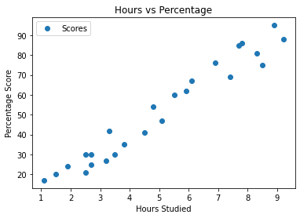

```python
dataset.plot(x='Hours', y='Scores', style='o')
plt.title('Hours vs Percentage')
plt.xlabel('Hours Studied')
plt.ylabel('Percentage Score')
plt.show()
```

```python
X = dataset.iloc[:, :-1].values
y = dataset.iloc[:, 1].values
```

```python
from sklearn.model_selection import train_test_split
X_train, X_test, y_train, y_test = train_test_split(X, y, test_size=0.2, random_state=0)
```

```python
from sklearn.linear_model import LinearRegression
regressor = LinearRegression()
regressor.fit(X_train, y_train)
```

```
LinearRegression()
```

```python
print(regressor.intercept_)
print(regressor.coef_)
```

```
2.018160041434683
[9.91065648]
```

Это означает, что на каждую единицу изменения в изученных часах изменение оценки составляет около 9,91%. Или, проще говоря, если студент учится на один час больше, чем готовился к экзамену ранее, он может рассчитывать на повышение на 9,91% баллов, полученных студентом ранее.

```python
y_pred = regressor.predict(X_test)
df = pd.DataFrame({'Actual': y_test, 'Predicted': y_pred})
df
```

|  | Actual | Predicted |
| --- | --- | --- |
| 0 | 20 | 16.884145 |
| 1 | 27 | 33.732261 |
| 2 | 69 | 75.357018 |
| 3 | 30 | 26.794801 |
| 4 | 62 | 60.491033 |

Последний шаг – оценить производительность алгоритма. Этот шаг особенно важен для сравнения того, насколько хорошо разные алгоритмы работают с конкретным набором данных. Пусть в столбце *Actual* записаны $y_1, ..., y_n$, а в столбце *Predicted* - $\widehat{y_1}, ..., \widehat{y_n}$.

Для алгоритмов регрессии обычно используются три основные показателя оценки:

Средняя абсолютная ошибка (MAE) – это среднее абсолютное значение ошибок. Он рассчитывается так: $\frac{1}{n} \sum_{i=1}^n |y_i - \widehat{y_i}|$

Среднеквадратичная ошибка (MSE) – это среднее значение квадратов ошибок, которое рассчитывается так: $\frac{1}{n} \sum_{i=1}^n |y_i - \widehat{y_i}|^2$

Среднеквадратичная ошибка (RMSE) – это квадратный корень из среднего квадрата ошибок: $\sqrt{\frac{1}{n} \sum_{i=1}^n |y_i - \widehat{y_i}|^2}$

```python
from sklearn import metrics
print('Mean Absolute Error:', metrics.mean_absolute_error(y_test, y_pred))
print('Mean Squared Error:', metrics.mean_squared_error(y_test, y_pred))
print('Root Mean Squared Error:', np.sqrt(metrics.mean_squared_error(y_test, y_pred)))
```

```
Mean Absolute Error: 4.183859899002975
Mean Squared Error: 21.5987693072174
Root Mean Squared Error: 4.6474476121003665
```